# Лечение гипертонии

72 пациента проходили лечение от гипертонии. Для лечения использовались три вида лекарств, при этом их эффект изучался как при использовании специальной диеты, так и в её отсутствии; кроме того, в половине случаев применялась психотерапия. Данные — артериальное давление пациента по окончании лечения.

Требуется сравнить эффективность методов лечения гипертонии.

```r
data <- read.table("hyper.txt", header=T)
data$drug <- factor(data$drug)
str(data)
```

```
## 'data.frame':    72 obs. of  4 variables:
##  $ biofeedback: Factor w/ 2 levels "absent","present": 2 2 2 2 2 2 2 2 2 2 ...
##  $ diet       : Factor w/ 2 levels "absent","present": 1 1 1 1 1 1 2 2 2 2 ...
##  $ drug       : Factor w/ 3 levels "1","2","3": 1 1 1 1 1 1 1 1 1 1 ...
##  $ pressure   : int  170 175 165 180 160 158 161 173 157 152 ...
```

```r
replications(pressure ~ biofeedback + diet + drug, data=data)
```

```
## biofeedback        diet        drug
##          36          36          24
```

1. Проведите трехфакторный дисперсионный анализ, используя все взаимодействия (в формуле для `aov` нужно положить в правой части `biofeedback * diet * drug`). Что можно сказать о значимости тройного взаимодействия? Можно ли интерпретировать значимость воздействия одиночных факторов в таком случае?

```r
# type your code here
summary(aov(pressure ~ biofeedback * diet * drug, data = data))
```

```
##                       Df Sum Sq Mean Sq F value   Pr(>F)
## biofeedback            1   2048    2048  13.072 0.000615 ***
## diet                   1   5202    5202  33.204 3.05e-07 ***
## drug                   2   3675    1837  11.729 5.02e-05 ***
## biofeedback:diet       1     32      32   0.204 0.652937
## biofeedback:drug       2    259     129   0.827 0.442457
## diet:drug              2    903     451   2.882 0.063815 .
## biofeedback:diet:drug  2   1075     537   3.431 0.038834 *
## Residuals             60   9400     157
## ---
## Signif. codes:  0 '***' 0.001 '**' 0.01 '*' 0.05 '.' 0.1 ' ' 1
```

2. Нарисуйте графики взаимодействия
- между психотерапией и использованием лекарств для каждого фиксированного значения диеты.
- между диетой и использованием лекарства при фиксированном значении психотерапии.

Можете ли вы проинтерпретировать данные графики?

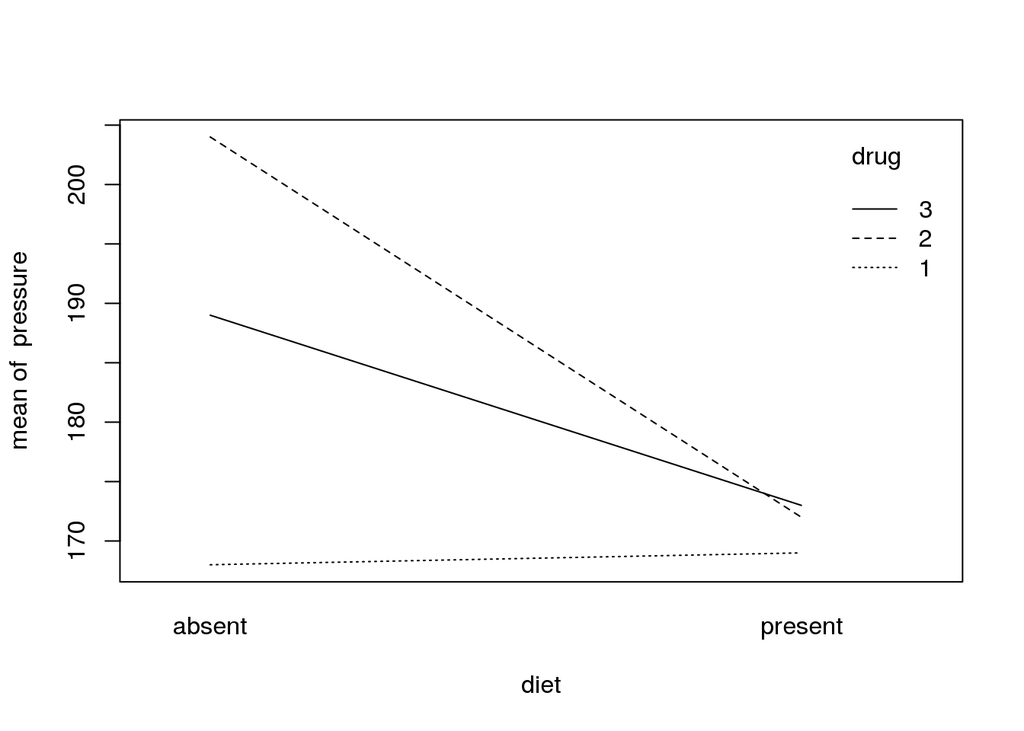

```r
# type your code here
with(data = subset(data, biofeedback == "present"), interaction.plot(diet, drug, pressure))
```

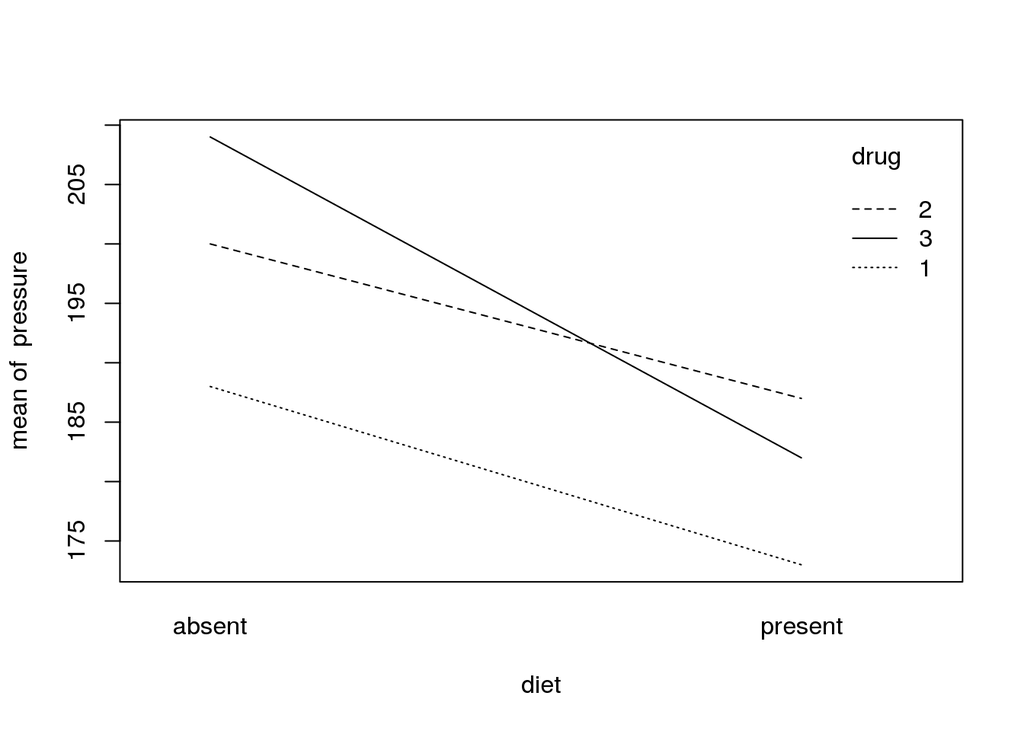

```r
with(data = subset(data, biofeedback == "absent"), interaction.plot(diet, drug, pressure))
```

3. Воспользуйтесь своими знаниями о дисперсионном анализе и проведите исследование:
- Проведите двухфакторный дисперсионный анализ для пациентов, проходящих и не проходящих психотерапию с целью выяснения значимых факторов, которые влияют на давление человека. В случае обнаружения значимых взаимодействий вам может понадобится поделить выборку на части еще раз и проводить уже однофакторный дисперсионный анализ.
  - В случае, если на каком-то из шагов вы получили значимое отклонение для какого-либо фактора (например, `drug`), примените критерий Тьюки для того, чтобы определить, каким препаратом и при каких условиях лучше снижать давление у людей и сделайте вывод.
  - В случае, если на каком-то из шагов вы получаете незначимое межфакторное взаимодействие, то далее также можно пользоваться критерием Тьюки, указав ему аргументом, какой конкретно фактор вас интересует (например, для лекарства указать `TukeyHSD(aov_object, which="drug")`)
  - Старайтесь на каждом шаге делать как можно больше графиков (например, `interaction.plot`, `boxplot`, `bar.err`, etc.)

```r
# type your code here
bioT = subset(data, biofeedback == "present")
bioF = subset(data, biofeedback == "absent")
r1 <- aov(pressure ~ diet * drug, data = bioT)
r2 <- aov(pressure ~ diet * drug, data = bioF)
model.tables(r1)
```

```
## Tables of effects
##
##  diet
## diet
##  absent present
##   7.833  -7.833
##
##  drug
## drug
##       1       2       3
## -10.667   8.833   1.833
##
##  diet:drug
##          drug
## diet      1      2      3
##   absent  -8.333  8.167  0.167
##   present  8.333 -8.167 -0.167
```

```r
model.tables(r2)
```

```
## Tables of effects
##
##  diet
## diet
##  absent present
##   9.167  -9.167
##
##  drug
## drug
##      1      2      3
## -9.333  3.667  5.667
##
##  diet:drug
##          drug
## diet      1      2      3
##   absent  -1.667 -2.667  4.333
##   present  1.667  2.667 -4.333
```

4. Подведите итоги исследования. Eсли пациент не проходит психотерапию, что можно сказать об эффективности диеты? об эффективности диеты при применении каждого из препаратов? o препаратах при соблюдении и не соблюдении диеты? Как вы бы ответили на все эти вопросы для пациентов, которые проходят психотерапию?

Чтобы сделать другие возможные выводы (например, оценить эффекты психотерапии и эффект диеты для тех, кто проходит психотерапию), нужно разбить трёхфакторный анализ по двум другим признакам. Это не входит в обязательные задания, но можете попробовать это сделать.

Maxwell S.E., Delaney H.D. **Designing Experiments and Analyzing Data: A Model Comparison Perspective**. (1990). Глава 8, стр. 325.